# An Introduction to Statistics with R

Steve Reilly, USA Today (sreilly@usatoday.com, @BySteveReilly)

NICAR 2019, Newport Beach, CA

Goals of the session

1. Introduction & workspace setup
2. Using R for descriptive and summary statistics
3. Linear regression
4. Multiple regression
5. Basic visualization

Data we will use

1. Diamond prices (pre-loaded practice dataset)
2. Massachusetts school test scores (pre-loaded practice dataset)
3. California school test scores (pre-loaded practice dataset)
4. NFL game TV ratings and 2016 presidential election results, 2016-2017 (USA Today analysis)

## Load libraries

```r
library("Ecdat")
library("ggplot2")
```

## 1. Diamond Prices

#### Load and explore data

```r
data(Diamond)
```

```r
View(Diamond)
?Diamond
```

We will use the `head` function to view the first five observations

```r
head(Diamond,5)
```

```
##   carat colour clarity certification price
## 1  0.30      D     VS2           GIA  1302
## 2  0.30      E     VS1           GIA  1510
## 3  0.30      G    VVS1           GIA  1510
## 4  0.30      G     VS1           GIA  1260
## 5  0.31      D     VS1           GIA  1641
```

We can also use the `tail` function to view the observations at the end of the dataset

```r
tail(Diamond)
```

```
##     carat colour clarity certification price
## 303  1.01      I    VVS1           HRD  8873
## 304  1.01      I     VS1           HRD  8175
## 305  1.02      F    VVS2           HRD 10796
## 306  1.06      H    VVS2           HRD  9890
## 307  1.02      H     VS2           HRD  8959
## 308  1.09      I    VVS2           HRD  9107
```

The `names` function allows us to see the names of the variables in the dataset.

```r
names(Diamond)
```

```
## [1] "carat"         "colour"        "clarity"       "certification"
## [5] "price"
```

```r
str(Diamond)
```

```
## 'data.frame':    308 obs. of  5 variables:
##  $ carat        : num  0.3 0.3 0.3 0.3 0.31 0.31 0.31 0.31 0.31 0.31 ...
##  $ colour       : Factor w/ 6 levels "D","E","F","G",..: 1 2 4 4 1 2 3 4 5 6 ...
##  $ clarity      : Factor w/ 5 levels "IF","VS1","VS2",..: 3 2 4 2 2 2 2 5 3 2 ...
##  $ certification: Factor w/ 3 levels "GIA","HRD","IGI": 1 1 1 1 1 1 1 1 1 1 ...
##  $ price        : int  1302 1510 1510 1260 1641 1555 1427 1427 1126 1126 ...
```

```r
summary(Diamond)
```

```
##      carat        colour clarity   certification     price
##  Min.   :0.1800   D:16   IF  :44   GIA:151       Min.   :  638
##  1st Qu.:0.3500   E:44   VS1 :81   HRD: 79       1st Qu.: 1625
##  Median :0.6200   F:82   VS2 :53   IGI: 78       Median : 4215
##  Mean   :0.6309   G:65   VVS1:52                 Mean   : 5019
##  3rd Qu.:0.8500   H:61   VVS2:78                 3rd Qu.: 7446
##  Max.   :1.1000   I:40                           Max.   :16008
```

### Basic visualization with trendline

Here, we use R’s base graphics system to create a simple scatterplot and add a trendline.

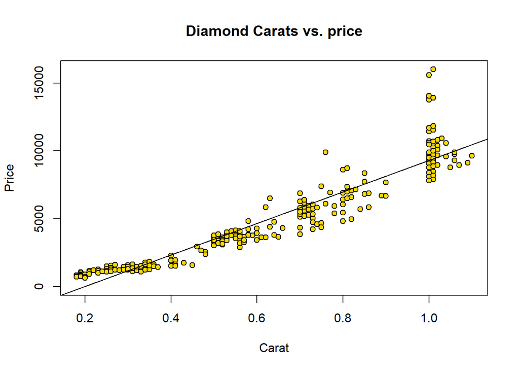

```r
plot(Diamond$carat, Diamond$price, main = "Diamond Carats vs. price", xlab = 'Carat', ylab = 'Price', pch = 21, bg = 'gold', ylim = c(0,16000))

abline(lm(Diamond$price~Diamond$carat))
```

### Visualize with ggplot

R’s powerful ggplot library allows us to build a more detailed visualization.

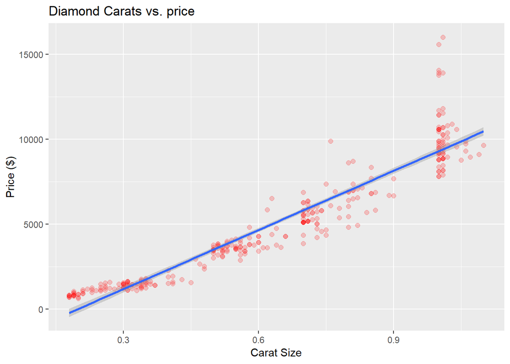

```r
ggplot(Diamond,aes(x=carat,y=price))+
  geom_point(colour="red",
             alpha = 0.2,
              size = 2) +
  geom_smooth(method="lm") +
  labs(x= "Carat Size",
         y = "Price ($)",
         title = "Diamond Carats vs. price")
```

### Linear regresion analysis

With two lines of code, we conduct a linear regression analysis. The dependent variable (or outcome, typically on Y axis) goes first, fillowed by a `~` and the independent variable (or predictor, typically on x axis).

```r
lm.out <- lm(Diamond$price~Diamond$carat)
summary(lm.out)
```

```
##
## Call:
## lm(formula = Diamond$price ~ Diamond$carat)
##
## Residuals:
##     Min      1Q  Median      3Q     Max
## -2264.7  -604.3  -116.1   435.1  6591.5
##
## Coefficients:
##               Estimate Std. Error t value Pr(>|t|)
## (Intercept)    -2298.4      158.5  -14.50   <2e-16 ***
## Diamond$carat  11598.9      230.1   50.41   <2e-16 ***
## ---
## Signif. codes:  0 '***' 0.001 '**' 0.01 '*' 0.05 '.' 0.1 ' ' 1
##
## Residual standard error: 1118 on 306 degrees of freedom
## Multiple R-squared:  0.8925, Adjusted R-squared:  0.8922
## F-statistic:  2541 on 1 and 306 DF,  p-value: < 2.2e-16
```

#### Interpret the results

- For every one-carat increase in the diamond, its value increases $11,598.90.
- This model is statistically significant at the 99.9% confidence level (p value < 0.001).
- There is a statistically significant relationship between the number of number of carats and price of a diamond.
- The adjusted R-squared is 0.89, meaning 89% of the variation in price is explained by carat.

## 2. Massachusetts Test Results

### Explore the data frame

```r
data(MCAS)
```

```r
?MCAS
View(MCAS)
```

```r
head(MCAS)
```

```
##   code municipa district regday specneed bilingua occupday totday  spc
## 1    1 ABINGTON Abington   4201  7375.69        0        0   4646 16.6
## 2    2    ACTON    Acton   4129  8573.99        0        0   4930  5.7
## 3    3 ACUSHNET Acushnet   3627  8081.72        0        0   4281  7.5
## 4    5   AGAWAM   Agawam   4015  8181.37        0        0   4826  8.6
## 5    7 AMESBURY Amesbury   4273  7037.22        0        0   4824  6.1
## 6    8  AMHERST  Amherst   5183 10595.80     6235        0   6454  7.7
##   speced lnchpct tchratio percap totsc4 totsc8 avgsalary     pctel
## 1   14.6    11.8     19.0 16.379    714    691   34.3600 0.0000000
## 2   17.4     2.5     22.6 25.792    731     NA   38.0630 1.2461059
## 3   12.1    14.1     19.3 14.040    704    693   32.4910 0.0000000
## 4   21.1    12.1     17.9 16.111    704    691   33.1060 0.3225806
## 5   16.8    17.4     17.5 15.423    701    699   34.4365 0.0000000
## 6   17.2    26.8     15.7 11.144    714     NA        NA 3.9215686
```

```r
tail(MCAS)
```

```
##     code   municipa   district regday specneed bilingua occupday totday
## 215  343 WINCHENDON Winchendon   3023  6597.85        0        0   3868
## 216  344 WINCHESTER Winchester   5631  9549.15        0        0   6264
## 217  346   WINTHROP   Winthrop   3986  8068.39        0        0   4805
## 218  347     WOBURN     Woburn   4945  8069.97        0        0   5712
## 219  348  WORCESTER  Worcester   4545  9719.62     6541     2951   5727
## 220  350   WRENTHAM   Wrentham   4066  8658.56        0        0   4751
##      spc speced lnchpct tchratio percap totsc4 totsc8 avgsalary     pctel
## 215  9.1   22.3    27.1     15.5 13.143    696    671   31.5560 0.0000000
## 216  6.8   11.1     3.3     16.9 30.615    737    730        NA 0.7874016
## 217 12.5   20.9    16.6     16.6 17.850    704    696        NA 2.5125628
## 218 17.2   16.2    16.9     18.4 18.155    721    709        NA 0.0000000
## 219  8.3   17.8    45.7     16.6 13.393    693    664   35.6155 3.0800822
## 220  4.3   11.7     4.6     19.2 15.856    720     NA   36.3665 0.0000000
```

```r
names(MCAS)
```

```
##  [1] "code"      "municipa"  "district"  "regday"    "specneed"
##  [6] "bilingua"  "occupday"  "totday"    "spc"       "speced"
## [11] "lnchpct"   "tchratio"  "percap"    "totsc4"    "totsc8"
## [16] "avgsalary" "pctel"
```

```r
summary(MCAS)
```

```
##       code           municipa       district       regday
##  Min.   :  1.0   ABINGTON:  1   Abington:  1   Min.   :2905
##  1st Qu.: 84.5   ACTON   :  1   Acton   :  1   1st Qu.:4065
##  Median :163.5   ACUSHNET:  1   Acushnet:  1   Median :4488
##  Mean   :170.9   AGAWAM  :  1   Agawam  :  1   Mean   :4605
##  3rd Qu.:269.2   AMESBURY:  1   Amesbury:  1   3rd Qu.:4972
##  Max.   :350.0   AMHERST :  1   Amherst :  1   Max.   :8759
##                  (Other) :214   (Other) :214
##     specneed        bilingua         occupday         totday
##  Min.   : 3832   Min.   :     0   Min.   :    0   Min.   :3465
##  1st Qu.: 7442   1st Qu.:     0   1st Qu.:    0   1st Qu.:4730
##  Median : 8354   Median :     0   Median :    0   Median :5155
##  Mean   : 8901   Mean   :  3037   Mean   : 1104   Mean   :5370
##  3rd Qu.: 9722   3rd Qu.:     0   3rd Qu.:    0   3rd Qu.:5789
##  Max.   :53569   Max.   :295140   Max.   :15088   Max.   :9868
##
##       spc             speced         lnchpct         tchratio
##  Min.   : 2.300   Min.   : 8.10   Min.   : 0.40   Min.   :11.40
##  1st Qu.: 6.100   1st Qu.:13.38   1st Qu.: 5.30   1st Qu.:15.80
##  Median : 7.800   Median :15.45   Median :10.55   Median :17.10
##  Mean   : 8.107   Mean   :15.97   Mean   :15.32   Mean   :17.34
##  3rd Qu.: 9.800   3rd Qu.:17.93   3rd Qu.:20.02   3rd Qu.:19.02
##  Max.   :18.400   Max.   :34.30   Max.   :76.20   Max.   :27.00
##  NA's   :9
##      percap           totsc4          totsc8        avgsalary
##  Min.   : 9.686   Min.   :658.0   Min.   :641.0   Min.   :24.96
##  1st Qu.:15.223   1st Qu.:701.0   1st Qu.:685.0   1st Qu.:33.80
##  Median :17.128   Median :711.0   Median :698.0   Median :35.88
##  Mean   :18.747   Mean   :709.8   Mean   :698.4   Mean   :35.99
##  3rd Qu.:20.376   3rd Qu.:720.0   3rd Qu.:712.0   3rd Qu.:37.96
##  Max.   :46.855   Max.   :740.0   Max.   :747.0   Max.   :44.49
##                                   NA's   :40      NA's   :25
##      pctel
##  Min.   : 0.0000
##  1st Qu.: 0.0000
##  Median : 0.0000
##  Mean   : 1.1177
##  3rd Qu.: 0.8859
##  Max.   :24.4939
##
```

```r
str(MCAS)
```

```
## 'data.frame':    220 obs. of  17 variables:
##  $ code     : int  1 2 3 5 7 8 9 10 14 16 ...
##  $ municipa : Factor w/ 220 levels "ABINGTON","ACTON",..: 1 2 3 4 5 6 7 8 9 10 ...
##  $ district : Factor w/ 220 levels "Abington","Acton",..: 1 2 3 4 5 6 7 8 9 10 ...
##  $ regday   : int  4201 4129 3627 4015 4273 5183 4685 5518 5009 3823 ...
##  $ specneed : num  7376 8574 8082 8181 7037 ...
##  $ bilingua : int  0 0 0 0 0 6235 0 0 0 12943 ...
##  $ occupday : int  0 0 0 0 0 0 0 0 0 11519 ...
##  $ totday   : int  4646 4930 4281 4826 4824 6454 5537 6405 5649 4814 ...
##  $ spc      : num  16.6 5.7 7.5 8.6 6.1 ...
##  $ speced   : num  14.6 17.4 12.1 21.1 16.8 ...
##  $ lnchpct  : num  11.8 2.5 14.1 12.1 17.4 ...
##  $ tchratio : num  19 22.6 19.3 17.9 17.5 ...
##  $ percap   : num  16.4 25.8 14 16.1 15.4 ...
##  $ totsc4   : int  714 731 704 704 701 714 725 717 702 701 ...
##  $ totsc8   : int  691 NA 693 691 699 NA 728 715 705 688 ...
##  $ avgsalary: num  34.4 38.1 32.5 33.1 34.4 ...
##  $ pctel    : num  0 1.246 0 0.323 0 ...
```

### Visualize the data

#### Create a histogram.

Is the data normally distributed? Let’s look at a histogram to see.

[figure not shown]

```r
a <- ggplot(MCAS,aes(totsc4))
a + geom_histogram(binwidth=10,color="black",fill="light blue") +
  scale_x_continuous(breaks=seq(0,50,10))+
  labs(x= "Fourth-grade test scores",
         y = "Student-teacher ratio",
         title = "Fourth-grade test scores and student-teacher ratio")
```

#### View scatterplot matrix

The scatterplot matrix helps by showing us visually which variables may be related. Here, we are selecting columns 4, 11, 12, 13, 14, and 16 and creating a grid of scatterplots comparing each variable with the other five. Which variables look like they may be related?

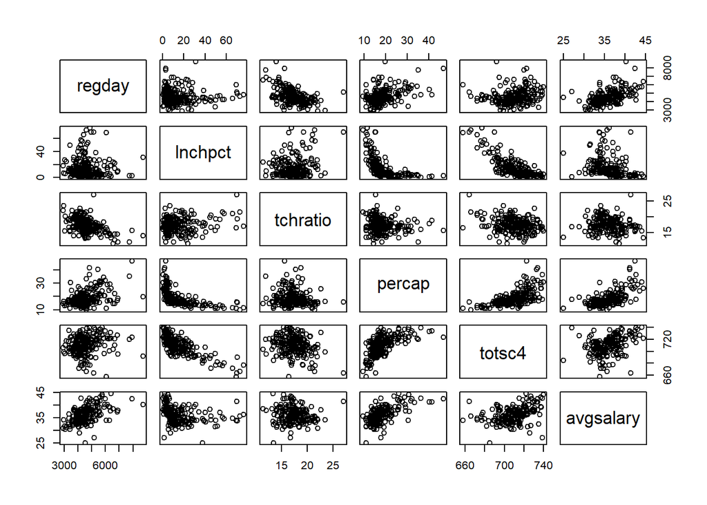

```r
plot(MCAS[,c(4,11:14,16)])
```

#### View scatterplot

It looks as though there may be a relationship between totsch4 (fourth-grade test score) and tchratio (student-teacher ratio). Let’s take a closer look.

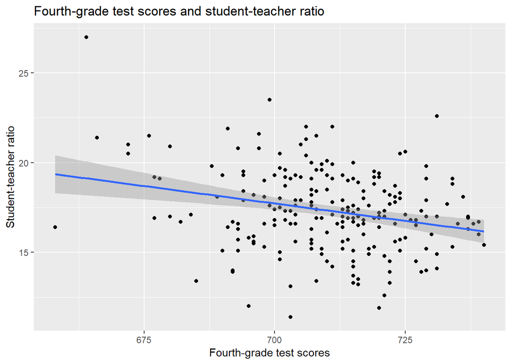

```r
ggplot(MCAS,aes(x=totsc4,y=tchratio))+ geom_point() + geom_smooth(method="lm") +
labs(x= "Fourth-grade test scores",
         y = "Student-teacher ratio",
         title = "Fourth-grade test scores and student-teacher ratio")
```

### Regression analysis

#### Bivariate regression: Test scores and student-teacher ratio

Here, we run a linear regression model to examine relationship between fourth-grade test scores and student-teacher ratio.

```r
Model1 <-lm(MCAS$totsc4~MCAS$tchratio)
summary(Model1)
```

```
##
## Call:
## lm(formula = MCAS$totsc4 ~ MCAS$tchratio)
##
## Residuals:
##     Min      1Q  Median      3Q     Max
## -53.449  -8.570   1.348   9.620  30.201
##
## Coefficients:
##               Estimate Std. Error t value Pr(>|t|)
## (Intercept)   739.6211     7.6038  97.270  < 2e-16 ***
## MCAS$tchratio  -1.7178     0.4347  -3.952 0.000105 ***
## ---
## Signif. codes:  0 '***' 0.001 '**' 0.01 '*' 0.05 '.' 0.1 ' ' 1
##
## Residual standard error: 14.65 on 218 degrees of freedom
## Multiple R-squared:  0.06685,    Adjusted R-squared:  0.06257
## F-statistic: 15.62 on 1 and 218 DF,  p-value: 0.0001048
```

#### Interpret the results

- A one-unit increase in the student-teacher ratio in this model decreases the average test score by 1.7 points.
- There is a statistically significant relationship between student-teacher ratio and test scores.
- The 99% confidence level says that we are 99% confident that the true value of the parameters that we are interested in lies within our confidence interval.
- The null hypothesis that the coefficient is zero can be rejected at the 1% significance level.
- However, this model only explains 6 percent of the variation in test scores.

### Linear regression: Test scores and student-teacher ratio+spending per pupil

Let’s examine another variable. Here, we run a linear regression model to examine the relationship between student-teacher ratio and fourth grade test scores.

```r
Model2 <-lm(MCAS$totsc4~MCAS$tchratio+MCAS$regday)
summary(Model2)
```

```
##
## Call:
## lm(formula = MCAS$totsc4 ~ MCAS$tchratio + MCAS$regday)
##
## Residuals:
##     Min      1Q  Median      3Q     Max
## -54.796  -7.821   1.121   9.690  29.584
##
## Coefficients:
##                 Estimate Std. Error t value Pr(>|t|)
## (Intercept)   730.954871  13.061680  55.962  < 2e-16 ***
## MCAS$tchratio  -1.503136   0.508337  -2.957  0.00345 **
## MCAS$regday     0.001073   0.001315   0.816  0.41520
## ---
## Signif. codes:  0 '***' 0.001 '**' 0.01 '*' 0.05 '.' 0.1 ' ' 1
##
## Residual standard error: 14.66 on 217 degrees of freedom
## Multiple R-squared:  0.0697, Adjusted R-squared:  0.06113
## F-statistic: 8.129 on 2 and 217 DF,  p-value: 0.000394
```

#### Interpret the results

- This model is also statistically significant, but still only explains about 6 percent of the variation in test scores.

```r
Model3 <-lm(MCAS$totsc4~MCAS$tchratio+MCAS$percap+MCAS$lnchpct)
summary(Model3)
```

```
##
## Call:
## lm(formula = MCAS$totsc4 ~ MCAS$tchratio + MCAS$percap + MCAS$lnchpct)
##
## Residuals:
##     Min      1Q  Median      3Q     Max
## -24.707  -5.072  -1.177   5.268  22.332
##
## Coefficients:
##                Estimate Std. Error t value Pr(>|t|)
## (Intercept)   718.98872    5.42681 132.488  < 2e-16 ***
## MCAS$tchratio  -0.70497    0.26290  -2.682  0.00789 **
## MCAS$percap     0.67214    0.12261   5.482 1.17e-07 ***
## MCAS$lnchpct   -0.62254    0.04748 -13.111  < 2e-16 ***
## ---
## Signif. codes:  0 '***' 0.001 '**' 0.01 '*' 0.05 '.' 0.1 ' ' 1
##
## Residual standard error: 8.692 on 216 degrees of freedom
## Multiple R-squared:  0.6744, Adjusted R-squared:  0.6698
## F-statistic: 149.1 on 3 and 216 DF,  p-value: < 2.2e-16
```

#### Interpret the results

- There is a statistically significant relationship between all variables included in this model and test scores.
- Model 3 is a much better fit than Models 1 and 2. This model explains 67 percent of the variation in test scores.
- In this model, a one-unit increase in student-teacher ratio decreases the average test score by 0.7 points after controlling per-capita income and students eligible for free/reduced lunch.

## 3. California test results

### Explore the data frame

```r
data(Caschool)
```

```r
View(Caschool)
```

```r
names(Caschool)
```

```
##  [1] "distcod"  "county"   "district" "grspan"   "enrltot"  "teachers"
##  [7] "calwpct"  "mealpct"  "computer" "testscr"  "compstu"  "expnstu"
## [13] "str"      "avginc"   "elpct"    "readscr"  "mathscr"
```

```r
str(Caschool)
```

```
## 'data.frame':    420 obs. of  17 variables:
##  $ distcod : int  75119 61499 61549 61457 61523 62042 68536 63834 62331 67306 ...
##  $ county  : Factor w/ 45 levels "Alameda","Butte",..: 1 2 2 2 2 6 29 11 6 25 ...
##  $ district: Factor w/ 409 levels "Ackerman Elementary",..: 362 214 367 132 270 53 152 383 263 94 ...
##  $ grspan  : Factor w/ 2 levels "KK-06","KK-08": 2 2 2 2 2 2 2 2 2 1 ...
##  $ enrltot : int  195 240 1550 243 1335 137 195 888 379 2247 ...
##  $ teachers: num  10.9 11.1 82.9 14 71.5 ...
##  $ calwpct : num  0.51 15.42 55.03 36.48 33.11 ...
##  $ mealpct : num  2.04 47.92 76.32 77.05 78.43 ...
##  $ computer: int  67 101 169 85 171 25 28 66 35 0 ...
##  $ testscr : num  691 661 644 648 641 ...
##  $ compstu : num  0.344 0.421 0.109 0.35 0.128 ...
##  $ expnstu : num  6385 5099 5502 7102 5236 ...
##  $ str     : num  17.9 21.5 18.7 17.4 18.7 ...
##  $ avginc  : num  22.69 9.82 8.98 8.98 9.08 ...
##  $ elpct   : num  0 4.58 30 0 13.86 ...
##  $ readscr : num  692 660 636 652 642 ...
##  $ mathscr : num  690 662 651 644 640 ...
```

```r
summary(Caschool)
```

```
##     distcod              county                         district
##  Min.   :61382   Sonoma     : 29   Lakeside Union Elementary:  3
##  1st Qu.:64308   Kern       : 27   Mountain View Elementary :  3
##  Median :67761   Los Angeles: 27   Jefferson Elementary     :  2
##  Mean   :67473   Tulare     : 24   Liberty Elementary       :  2
##  3rd Qu.:70419   San Diego  : 21   Ocean View Elementary    :  2
##  Max.   :75440   Santa Clara: 20   Pacific Union Elementary :  2
##                  (Other)    :272   (Other)                  :406
##    grspan       enrltot           teachers          calwpct
##  KK-06: 61   Min.   :   81.0   Min.   :   4.85   Min.   : 0.000
##  KK-08:359   1st Qu.:  379.0   1st Qu.:  19.66   1st Qu.: 4.395
##              Median :  950.5   Median :  48.56   Median :10.520
##              Mean   : 2628.8   Mean   : 129.07   Mean   :13.246
##              3rd Qu.: 3008.0   3rd Qu.: 146.35   3rd Qu.:18.981
##              Max.   :27176.0   Max.   :1429.00   Max.   :78.994
##
##     mealpct          computer         testscr         compstu
##  Min.   :  0.00   Min.   :   0.0   Min.   :605.5   Min.   :0.00000
##  1st Qu.: 23.28   1st Qu.:  46.0   1st Qu.:640.0   1st Qu.:0.09377
##  Median : 41.75   Median : 117.5   Median :654.5   Median :0.12546
##  Mean   : 44.71   Mean   : 303.4   Mean   :654.2   Mean   :0.13593
##  3rd Qu.: 66.86   3rd Qu.: 375.2   3rd Qu.:666.7   3rd Qu.:0.16447
##  Max.   :100.00   Max.   :3324.0   Max.   :706.8   Max.   :0.42083
##
##     expnstu          str            avginc           elpct
##  Min.   :3926   Min.   :14.00   Min.   : 5.335   Min.   : 0.000
##  1st Qu.:4906   1st Qu.:18.58   1st Qu.:10.639   1st Qu.: 1.941
##  Median :5215   Median :19.72   Median :13.728   Median : 8.778
##  Mean   :5312   Mean   :19.64   Mean   :15.317   Mean   :15.768
##  3rd Qu.:5601   3rd Qu.:20.87   3rd Qu.:17.629   3rd Qu.:22.970
##  Max.   :7712   Max.   :25.80   Max.   :55.328   Max.   :85.540
##
##     readscr         mathscr
##  Min.   :604.5   Min.   :605.4
##  1st Qu.:640.4   1st Qu.:639.4
##  Median :655.8   Median :652.5
##  Mean   :655.0   Mean   :653.3
##  3rd Qu.:668.7   3rd Qu.:665.9
##  Max.   :704.0   Max.   :709.5
##
```

```r
head(Caschool)
```

```
##   distcod  county                        district grspan enrltot teachers
## 1   75119 Alameda              Sunol Glen Unified  KK-08     195    10.90
## 2   61499   Butte            Manzanita Elementary  KK-08     240    11.15
## 3   61549   Butte     Thermalito Union Elementary  KK-08    1550    82.90
## 4   61457   Butte Golden Feather Union Elementary  KK-08     243    14.00
## 5   61523   Butte        Palermo Union Elementary  KK-08    1335    71.50
## 6   62042  Fresno         Burrel Union Elementary  KK-08     137     6.40
##   calwpct mealpct computer testscr   compstu  expnstu      str    avginc
## 1  0.5102  2.0408       67  690.80 0.3435898 6384.911 17.88991 22.690001
## 2 15.4167 47.9167      101  661.20 0.4208333 5099.381 21.52466  9.824000
## 3 55.0323 76.3226      169  643.60 0.1090323 5501.955 18.69723  8.978000
## 4 36.4754 77.0492       85  647.70 0.3497942 7101.831 17.35714  8.978000
## 5 33.1086 78.4270      171  640.85 0.1280899 5235.988 18.67133  9.080333
## 6 12.3188 86.9565       25  605.55 0.1824818 5580.147 21.40625 10.415000
##       elpct readscr mathscr
## 1  0.000000   691.6   690.0
## 2  4.583333   660.5   661.9
## 3 30.000002   636.3   650.9
## 4  0.000000   651.9   643.5
## 5 13.857677   641.8   639.9
## 6 12.408759   605.7   605.4
```

### Visualize the data

#### Visualize individual variables

Another way to explore the data visually is to look histograms of individual variables. Let’s examine at a few variables that may be of interest to us.

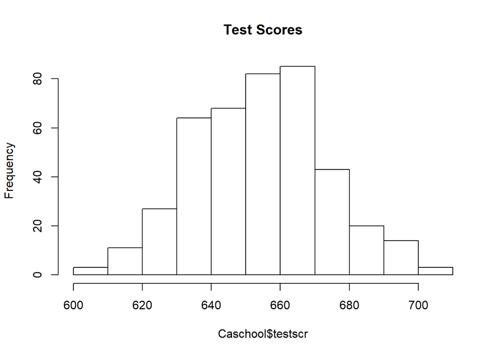

```r
hist(Caschool$testscr, main="Test Scores")
```

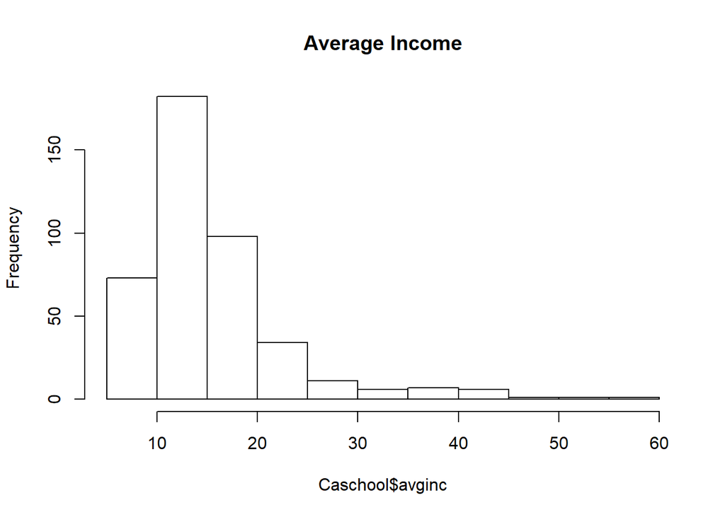

```r
hist(Caschool$avginc, main="Average Income")
```

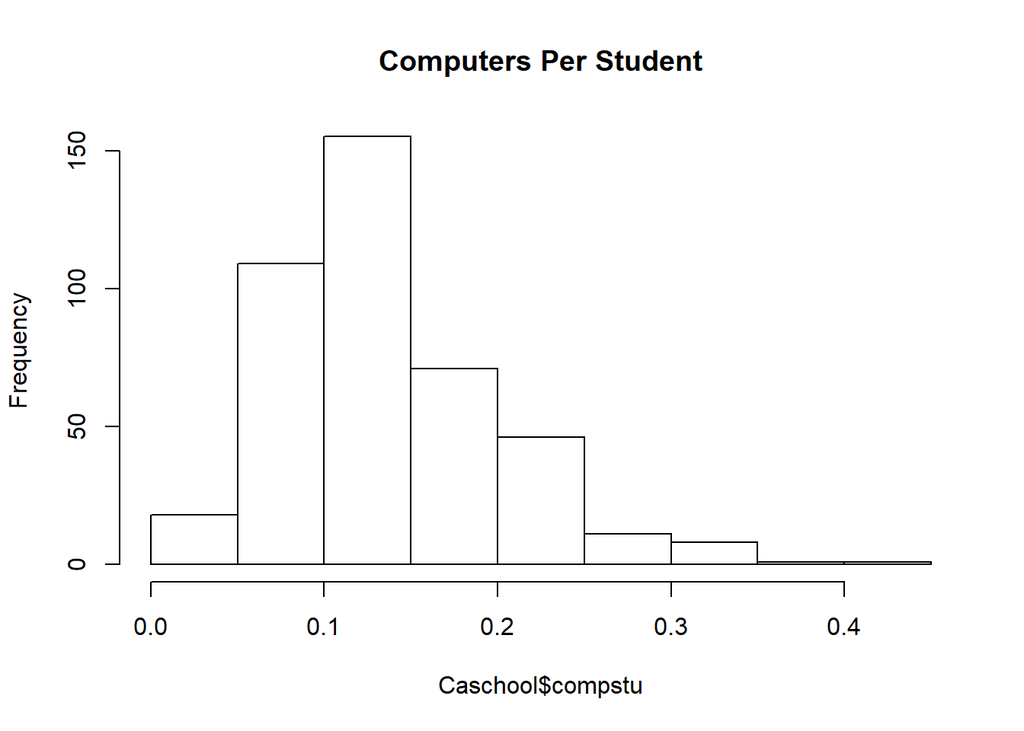

```r
hist(Caschool$compstu, main="Computers Per Student")
```

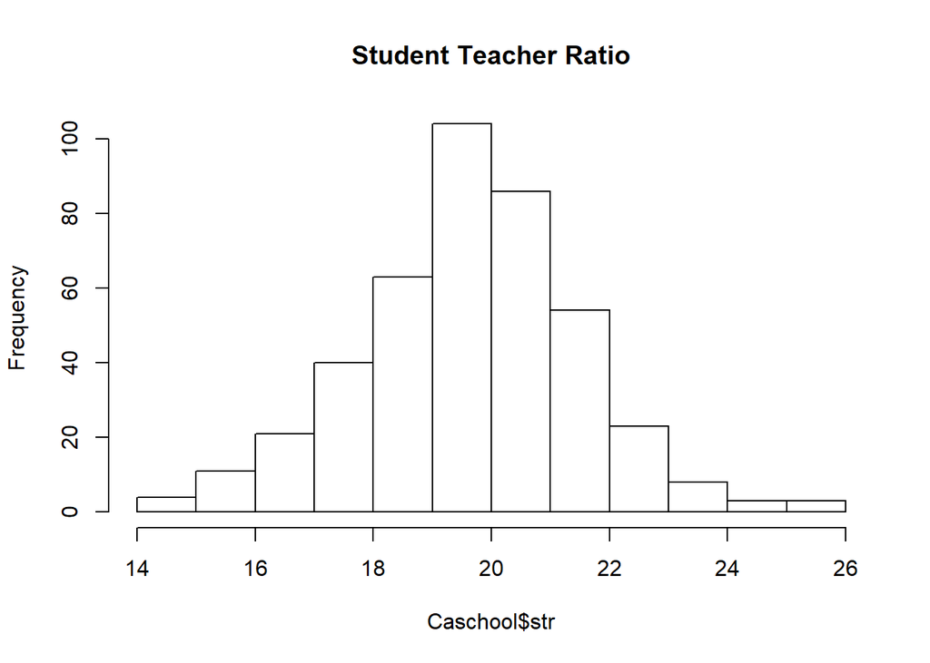

```r
hist(Caschool$str, main="Student Teacher Ratio")
```

#### View scatterplot matrix

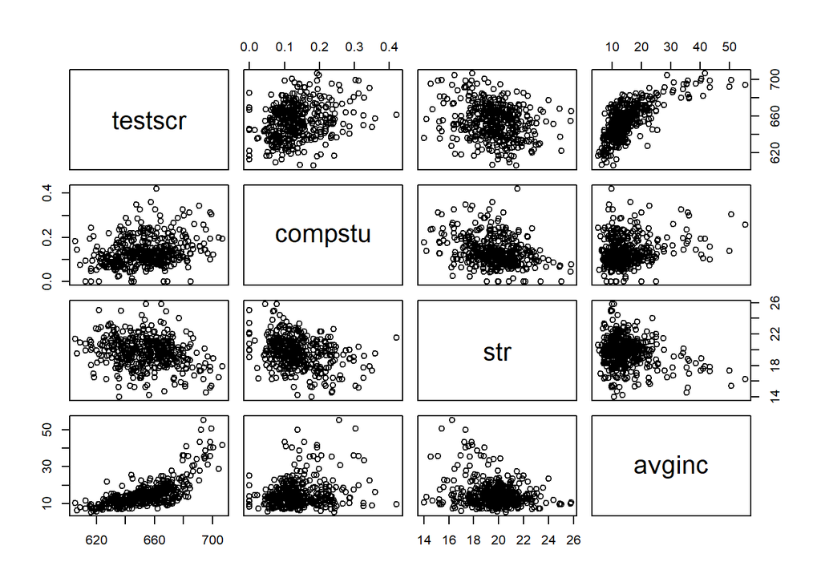

```r
plot(Caschool[,c(10,11,13,14)])
```

### Regression analysis

#### Linear regression: Test scores and student-teacher ratio

Let’s examine the relationship between test scores and student-teacher ratio.

```r
Model4 <-lm(Caschool$testscr~Caschool$str)
summary(Model4)
```

```
##
## Call:
## lm(formula = Caschool$testscr ~ Caschool$str)
##
## Residuals:
##     Min      1Q  Median      3Q     Max
## -47.727 -14.251   0.483  12.822  48.540
##
## Coefficients:
##              Estimate Std. Error t value Pr(>|t|)
## (Intercept)  698.9330     9.4675  73.825  < 2e-16 ***
## Caschool$str  -2.2798     0.4798  -4.751 2.78e-06 ***
## ---
## Signif. codes:  0 '***' 0.001 '**' 0.01 '*' 0.05 '.' 0.1 ' ' 1
##
## Residual standard error: 18.58 on 418 degrees of freedom
## Multiple R-squared:  0.05124,    Adjusted R-squared:  0.04897
## F-statistic: 22.58 on 1 and 418 DF,  p-value: 2.783e-06
```

#### Interpret the results

- There is a statistically significant relationship between student-teacher ratio and test scores.
- The null hypothesis that the coefficient is zero can be rejected at the 0.1% significance level.
- However, this model only explains roughly 5 percent of the variation in test scores.
- A one-unit increase in the student-teacher ratio in this model decreases the average test score by 2.3 points.

### Multiple regression: Test scores and student-teacher ratio + computers-per-student

Let’s try and build a model which more closely predicts test scores by adding computers-per-student as a second predictor variable.

```r
Model5 <-lm(Caschool$testscr~Caschool$str+Caschool$compstu)
summary(Model5)
```

```
##
## Call:
## lm(formula = Caschool$testscr ~ Caschool$str + Caschool$compstu)
##
## Residuals:
##    Min     1Q Median     3Q    Max
## -48.83 -14.03  -1.47  12.89  46.00
##
## Coefficients:
##                  Estimate Std. Error t value Pr(>|t|)
## (Intercept)      676.5830    10.4808  64.555  < 2e-16 ***
## Caschool$str      -1.5928     0.4928  -3.232  0.00132 **
## Caschool$compstu  65.1599    14.3513   4.540 7.36e-06 ***
## ---
## Signif. codes:  0 '***' 0.001 '**' 0.01 '*' 0.05 '.' 0.1 ' ' 1
##
## Residual standard error: 18.16 on 417 degrees of freedom
## Multiple R-squared:  0.09593,    Adjusted R-squared:  0.0916
## F-statistic: 22.12 on 2 and 417 DF,  p-value: 7.375e-10
```

### Multiple regression analysis: Test scores and student-teacher ratio + computers-per-student + average income

Let’s try one more regression model adding average household income as a predictor variable.

```r
Model6 <- lm(Caschool$testscr~Caschool$str+Caschool$compstu+Caschool$avginc)
summary(Model6)
```

```
##
## Call:
## lm(formula = Caschool$testscr ~ Caschool$str + Caschool$compstu +
##     Caschool$avginc)
##
## Residuals:
##     Min      1Q  Median      3Q     Max
## -41.067  -9.114   0.817   8.946  34.910
##
## Coefficients:
##                  Estimate Std. Error t value Pr(>|t|)
## (Intercept)      627.1742     8.0090  78.309  < 2e-16 ***
## Caschool$str      -0.2882     0.3633  -0.793 0.428040
## Caschool$compstu  37.9366    10.4939   3.615 0.000337 ***
## Caschool$avginc    1.7946     0.0923  19.444  < 2e-16 ***
## ---
## Signif. codes:  0 '***' 0.001 '**' 0.01 '*' 0.05 '.' 0.1 ' ' 1
##
## Residual standard error: 13.16 on 416 degrees of freedom
## Multiple R-squared:  0.5264, Adjusted R-squared:  0.5229
## F-statistic: 154.1 on 3 and 416 DF,  p-value: < 2.2e-16
```

#### Interpret the results

- After controlling for both computers-per-student and average income, student-teacher ratio is no longer staistically significat at th 95 percent confidence level.
- This does not mean there isn’t a real-world relationship between student-teacher ratio and student test scores.
- Importantly, note that this model still only accounts for 52% of the variation in student test scores. There must be omitted variables.
- This analysis shows there is need for further inquiry. We do some reporting and analysis to find what other omitted variables need to be factored into the analysis.

## 4. NFL TV Ratings and politics

> Ratings for NFL football are way down except before game starts, when people tune in to see whether or not our country will be disrespected!

> — Donald J. Trump (@realDonaldTrump) [September 26, 2017](https://twitter.com/realDonaldTrump/status/912624892239077376?ref_src=twsrc%5Etfw)

#### Hypothesis test

Null hypothesis: There is no stastically significant relationship between political support for President Trump and NFL ratings.

Alternative hypothesis: There is a statistically significant relationship between political support for President Trump and NFL ratings.

#### Import data

```r
NFL.ratings <- read.csv("https://raw.githubusercontent.com/steve-reilly/nicar19/master/nfl_ratings.csv")
```

#### View summary statistics

```r
View(NFL.ratings)
```

```r
str(NFL.ratings)
```

```
## 'data.frame':    37 obs. of  5 variables:
##  $ ï..Row.Labels  : Factor w/ 37 levels "Atlanta","Boston (Manchester)",..: 1 2 3 4 5 6 7 8 9 10 ...
##  $ trump.percent  : num  0.497 0.374 0.542 0.558 0.327 ...
##  $ avg.rating.2016: num  11.51 8.94 13.78 13.97 13.29 ...
##  $ avg.rating.2017: num  13.1 10.2 14.4 13.3 11.4 ...
##  $ ratings.change : num  1.551 1.264 0.637 -0.702 -1.9 ...
```

```r
summary(NFL.ratings)
```

```
##              ï..Row.Labels trump.percent    avg.rating.2016
##  Atlanta            : 1    Min.   :0.3267   Min.   : 8.642
##  Boston (Manchester): 1    1st Qu.:0.4237   1st Qu.:11.911
##  Buffalo            : 1    Median :0.5185   Median :13.779
##  Charlotte          : 1    Mean   :0.4943   Mean   :14.765
##  Chicago            : 1    3rd Qu.:0.5583   3rd Qu.:17.648
##  Cincinnati         : 1    Max.   :0.6721   Max.   :23.264
##  (Other)            :31
##  avg.rating.2017  ratings.change
##  Min.   : 9.066   Min.   :-7.2377
##  1st Qu.:11.673   1st Qu.:-1.8540
##  Median :14.022   Median :-0.7018
##  Mean   :13.869   Mean   :-0.8957
##  3rd Qu.:15.973   3rd Qu.: 0.4235
##  Max.   :20.352   Max.   : 3.3960
##
```

#### Visualize data

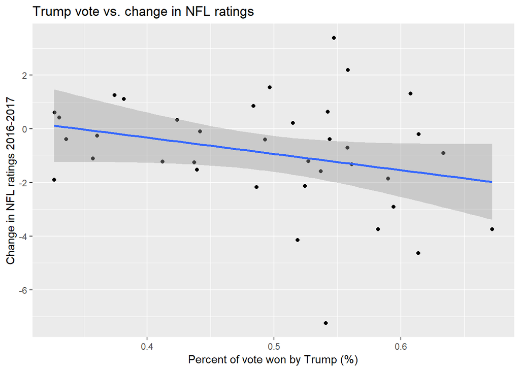

```r
ggplot(NFL.ratings,aes(y=NFL.ratings$ratings.change, x=NFL.ratings$trump.percent))+ geom_point() + geom_smooth(method="lm") +
  labs(x= "Percent of vote won by Trump (%)",
       y = "Change in NFL ratings 2016-2017",
       title = "Trump vote vs. change in NFL ratings")
```

### Linear regresion analysis: Ratings change vs. Trump Winner

```r
lm.out <- lm(NFL.ratings$ratings.change~NFL.ratings$trump.percent)
summary(lm.out)
```

```
##
## Call:
## lm(formula = NFL.ratings$ratings.change ~ NFL.ratings$trump.percent)
##
## Residuals:
##     Min      1Q  Median      3Q     Max
## -6.0594 -1.0401 -0.0231  1.2379  4.6133
##
## Coefficients:
##                           Estimate Std. Error t value Pr(>|t|)
## (Intercept)                  2.105      1.735   1.213    0.233
## NFL.ratings$trump.percent   -6.070      3.447  -1.761    0.087 .
## ---
## Signif. codes:  0 '***' 0.001 '**' 0.01 '*' 0.05 '.' 0.1 ' ' 1
##
## Residual standard error: 2.007 on 35 degrees of freedom
## Multiple R-squared:  0.08138,    Adjusted R-squared:  0.05514
## F-statistic: 3.101 on 1 and 35 DF,  p-value: 0.08699
```